# Final Project

- Deadlines
- Introduction
  - The Olinde Career Center and its Stakeholders
  - The Database
- Your Goal
- Getting Started with the Project
  - Developing a (non-trivial) Research Question
  - Integrating External Datasource
  - Organize your Project Repository
  - Reproducibility
- Grading criteria
- Seeking help from the R Community

### Deadlines

- March, 27: Schedule your presentation
- April, 3: The README on your GitHub repo should at least present what is your research question and what artifact you want to develop (pdf, HTML page, dashboard, etc.)
- April, 23-27: Presentation

# Introduction

## The Olinde Career Center and its Stakeholders

The [Olinde Career Center](http://www.lsu.edu/students/careercenter/) is the LSU office in charge of assisting LSU students and companies with their career related queries. One of their most valuable activities is to collect LSU graduates' data through an online survey that they distribute via [Qualtrics](https://www.qualtrics.com/). The survey {#survey} is distributed at every commencement to all of the students that graduated (i.e., May, August, and December). Since May 2016, a follow-up survey has been redistributed to all those students who did not claim to be employed full-time at graduation. There are different stakeholders interested in harnessing career data:

- Schools/Departments are interested in learning about the placement of their students, their average salary and data which can signal the marketability of a degree
- Office of Research and Economic Development is interested in extracting actionable knowledge from the data. For instance, are TOPS scholarship retaining alumni in Lousiana after graduation? Are minimum GPA criteria useful in selecting high performing students?
- Government agencies (e.g., [National Science Foundation](https://www.nsf.gov/)) are interested in longitudinal and comprehensive reports usually over a 3-5 years period.

## The Database

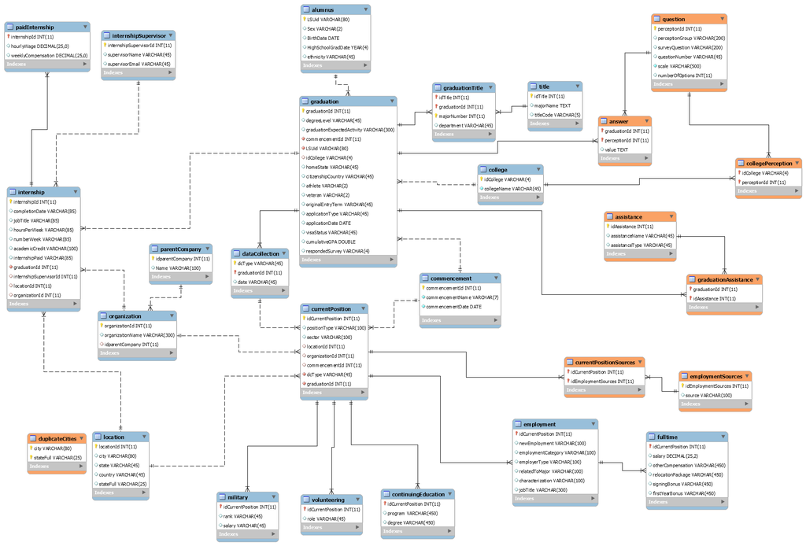

For a description of the variables in the model, take a look at the data dictionary.

# Your Goal

Your team needs to support one of the stakeholders by developing an artifact to support the their decision-making process. The artifact can be static (e.g., PDF report(s)) or interactive (HTML page) and should provide actionable/valuable insights using the data from the Graduate Survey Database.

There are no restrictions regarding the final output of your work. Although an HTML page is arguably the most portable output, often a printable PDF-document might fit better to the requirements of your client. Every format has its peculiar strengths and presents different challenges.

Your final presentation (25-30mins) should convey the value of your artifact and address at least:

1. What is your research question/the problem you are trying to solve?
2. What are the principles that guided the design of your artifact: Who are the users? How are they supposed to use the artifact?
3. Presenting your results and limitations. Are there any technical aspects that would be valuable sharing in class? That would also help to appreciate your effort.

There are no specific guidelines regarding the presentation format. It can be an HTML, pdf or powerpoint. You might have a single person present or split the presentation among the group members.

We will hodl the presentations in the conference room 2240 during the last week of class (23-27 April). Please discuss within your group your availabilities and let me know by **Tuesday, 27 March** when you can present - I will reserve the conference room.

# Getting Started with the Project

## Developing a (non-trivial) Research Question

Picking a research question that is **relevant** to our stakeholders is crucial, but it also needs to be non-trivial. Ideally, you want to address a problem that a stakeholder could hardly answer leveraging anecdotal knowledge our intuitive thinking. An example of a relevant but trivial question would be: Do majors have different expected salaries? Answering this question providing average wages by colleges is valuable information, but you could move to a higher level of sophistication. For instance, do they vary because specific majors usually move to states offering higher salaries? And if yes, would the salary gap balance out the cost of living in a different state?

To answer some of this question, you want to include multiple variables in your analysis. Some of them (e.g., cost of living) may not even be available in our database but are easy to find online.

Example of how to elaborate on a research question:

- Very Easy: average salary of graduates
- Easy: Average salary by state
- Medium: Is the average salary by state inflated by specific big cities?
- Advanced: Is a higher/lower salary by state proportional to the cost of living in the state?

## Integrating External Datasource

Aggregating external data sources can be beneficial to enhance the informativeness of the analysis. If you get lucky, the dataset you are looking for might be available online on platforms such as [statista](https://www.statista.com/) or kaggle. Other times extracting the information you are looking for is less straightforward and might require API access or web scraping. For instance, [glassdoor.com](https://www.glassdoor.com/) or [LinkedIn](https://www.linkedin.com/) might be valuable resources for collecting career data.

If you choose to use external data sources, do not forget to reference them. Preferably, you should include the datasets you are using or make sure that the source of your data is verifiable. If you are web scraping, you might want to save the script of your scraper.

## Organize your Project Repository

The project should be hosted online on a GitHub repo. The README file on the first page should be the "abstract" of your project. It should present the issue that you investigate and explain how the value of the artifact in solving an issue or responding to a resaerch question. You may even include the major findings, screenshots of your presentation or anything that would motivate a user even to take a look at what your code does.

To make your repository more accessible, try to keep your files tidy. For instance, a possible structure of your folder may be:

```
\R          #sometimes it is useful to split your code in multiple R scripts
\figure     #ggplot charts, logos, figures and generally visual static content
\data       #the dataset you are using (consider whether you want them in .csv/.tvs or .RDta)
\Rmd        #.Rmd files for your report(s)
index.html  #the html version of your presentation
README      #this is your "abstract""
```

## Reproducibility

The Olinde database is not an ad hoc database for learning purposes. Many records come from open text fields, which means misspellings, missing values, and oddities due to actual users typing in information might occur. If a major issue with the data arises, we may consider fixing it along the way. Thus, you want your code to be as robust and reproducible as possible. For instance, what if we updated the records for a new commencement to the database? Would your code still run smoothly?

# Grading criteria

This project is the chance for you to explore the magnificent world of R. The main goal is to build on what you have learned so far to independently explore new tools to enhance the investigation of a research question of your choice. Some of the aspects that would make a good project are:

1. Picking a research question that is **relevant** to our stakeholders.
2. **Explore new tools** that help you investigating the research question or presenting the findings. Some examples are: Using a new library for plotting, creating a template for your pdf reports, use statistical modeling.
3. **Integrate external resources*. Looking at the bigger picture is sometimes critical to fully understand what the data might tell us. Variables such as unemployment rate of LSU graduates might become a lot more meaningful when framed relatively to other schools. However, that information is not available in the Olinde DB but may come from using external resources.
4. What did you find? **Findings** do not only entail what you know but also the **limitations** of your results. For instance, is there any variables that you would recommend collecting to enhance the validity of your analysis?
5. Make sure that your analysis is **reproducible**. Ideally, anyone should be able to run your code an replicate the results.
6. Provide **readable code**. It will be faster for your team to recall what your code does. There are multiple ways to produce the same output, but not every way is equally correct.

Grades will virtually be the same for every member of the team unless evidence of severe misconduct arises. Obviously, every team will have members who are stronger in coding than others; but coding is not the only skill in play. Make sure you organize your project such that each member can productively contribute to the final output.

# Seeking help from the R Community

If you need help with your code, you should consider searching/posting on [Stackoverflow](https://stackoverflow.com/). Before you post, make sure you reduce your problem into a [reproducible example](https://stackoverflow.com/questions/5963269/how-to-make-a-great-r-reproducible-example). Issues that are not reproducible are unlikely to receive any responses at all.

Also, you can tag [me](https://github.com/DarioBoh) in your GitHub issues and feel free to message me a reminder if I do not respond within 24hours. I will not provide a full working solution, but I will do my best to help you troubleshoot or to point you to a resource that might help you solving the problem.

Our Slack group. Others may be dealing with a similar issue, although they are investigating a different research question. Do not be too jeaulous of your code, which is only a tool and not the ultimate goal of the project. Sharing your code is a good way to receive feedback on it.